# **STAT I512, Honglang Wang (hlwang)**

# **Kyle McCrocklin**

## Problem 1:

```r
library(MASS)
library(ggplot2)
library(corrplot)
library(splines)
set.seed(42)

load("G:/Other computers/My Laptop/Google Drive/STAT512 Projects/Final Exam/meps512.RData")

# Predictors:
# AGE42X, ADBMI42, MNHLTH42, FAMINC18, RACETHX, SEX
# age, BMI, perceived mental health status, family income, race and gender

# Response:
# TOTEXP18 = total adult medical expenditures.

# Convert to factors
data$MNHLTH42 = as.factor(data$MNHLTH42)
data$RACETHX = as.factor(data$RACETHX)
data$SEX = as.factor(data$SEX)

colSums(is.na(data))
```

```
## TOTEXP18   AGE42X  ADBMI42 MNHLTH42 FAMINC18  RACETHX      SEX
##        0        0        0        0        0        0        0
```

```r
m1 = lm(TOTEXP18 ~ AGE42X, data=data)
cat('\nMODEL 1:')
```

```
##
## MODEL 1:
```

```r
summary(m1)
```

```
##
## Call:
## lm(formula = TOTEXP18 ~ AGE42X, data = data)
##
## Residuals:
##    Min     1Q Median     3Q    Max
## -14904  -6955  -3807   -538 801046
##
## Coefficients:
##              Estimate Std. Error t value Pr(>|t|)
## (Intercept) -2385.134    407.137  -5.858 4.76e-09 ***
## AGE42X        203.406      7.691  26.448  < 2e-16 ***
## ---
## Signif. codes:  0 '***' 0.001 '**' 0.01 '*' 0.05 '.' 0.1 ' ' 1
##
## Residual standard error: 18930 on 18250 degrees of freedom
## Multiple R-squared:  0.03691,    Adjusted R-squared:  0.03686
## F-statistic: 699.5 on 1 and 18250 DF,  p-value: < 2.2e-16
```

```r
m2 = lm(TOTEXP18 ~ AGE42X + SEX, data=data)
cat('\nMODEL 2:')
```

```
##
## MODEL 2:
```

```r
summary(m2)
```

```
##
## Call:
## lm(formula = TOTEXP18 ~ AGE42X + SEX, data = data)
##
## Residuals:
##    Min     1Q Median     3Q    Max
## -15414  -6908  -3791   -465 800523
##
## Coefficients:
##              Estimate Std. Error t value Pr(>|t|)
## (Intercept) -1848.028    428.466  -4.313 1.62e-05 ***
## AGE42X        203.081      7.688  26.415  < 2e-16 ***
## SEXMALE     -1125.788    280.895  -4.008 6.15e-05 ***
## ---
## Signif. codes:  0 '***' 0.001 '**' 0.01 '*' 0.05 '.' 0.1 ' ' 1
##
## Residual standard error: 18920 on 18249 degrees of freedom
## Multiple R-squared:  0.03776,    Adjusted R-squared:  0.03765
## F-statistic: 358.1 on 2 and 18249 DF,  p-value: < 2.2e-16
```

```r
m3 = lm(TOTEXP18 ~ AGE42X * SEX, data=data)
cat('\nMODEL 3:')
```

```
##
## MODEL 3:
```

```r
summary(m3)
```

```
##
## Call:
## lm(formula = TOTEXP18 ~ AGE42X * SEX, data = data)
##
## Residuals:
##    Min     1Q Median     3Q    Max
## -15308  -6963  -3830   -181 800381
##
## Coefficients:
##                Estimate Std. Error t value Pr(>|t|)
## (Intercept)     -643.38     554.06  -1.161  0.24557
## AGE42X           178.93      10.43  17.162  < 2e-16 ***
## SEXMALE        -3752.99     816.28  -4.598  4.3e-06 ***
## AGE42X:SEXMALE    52.89      15.43   3.428  0.00061 ***
## ---
## Signif. codes:  0 '***' 0.001 '**' 0.01 '*' 0.05 '.' 0.1 ' ' 1
##
## Residual standard error: 18920 on 18248 degrees of freedom
## Multiple R-squared:  0.03838,    Adjusted R-squared:  0.03822
## F-statistic: 242.8 on 3 and 18248 DF,  p-value: < 2.2e-16
```

### a)

In model 1, β1 represents the change in medical expenditure for an increase in age of 1 year. This captures the relationship between age and medical expenditure without accounting for the potential influence of any other variables.

In model 2, β1 represents the change in medical expenditure for an increase in age of 1 year while holding gender constant. This isolates the effects of each predictor from the other which gives a more precise understanding of each predictors contribution to the response.

### b)

The change in expected response if age increases by 1 while sex held fixed for Model 2 is an increase of $203.08

### c)

The change in expected response if age increases by 1 while sex held fixed for Model 3 is an increase of… for females (X2=0): β1 = $178.93 for males (X2=1): β1 + β3 = 178.93 + 52.89 = $231.82

## Problem 2:

###Print summary statistics

```r
# summary statistics
cat('\nContinuous variables:\n')
```

```
##
## Continuous variables:
```

```r
summary(data[, c("TOTEXP18", "AGE42X", "ADBMI42", "FAMINC18")])
```

```
##     TOTEXP18          AGE42X        ADBMI42         FAMINC18
##  Min.   :     0   Min.   :18.0   Min.   : 0.10   Min.   :-309948
##  1st Qu.:   400   1st Qu.:34.0   1st Qu.:23.70   1st Qu.:  27130
##  Median :  2024   Median :50.0   Median :27.30   Median :  56838
##  Mean   :  7725   Mean   :49.7   Mean   :28.15   Mean   :  75915
##  3rd Qu.:  7087   3rd Qu.:64.0   3rd Qu.:31.90   3rd Qu.: 104718
##  Max.   :807611   Max.   :85.0   Max.   :71.10   Max.   : 583219
```

```r
cat('\nMental health:')
```

```
##
## Mental health:
```

```r
table(data$MNHLTH42)
```

```
##
## EXCELLENT      FAIR      GOOD   INVALID      POOR VERY GOOD
##      5868      1405      4904         6       301      5768
```

```r
cat('\nRace:')
```

```
##
## Race:
```

```r
table(data$RACETHX)
```

```
##
##        ASIAN ONLY        BLACK ONLY          HISPANIC OTHER OR MULTIPLE
##               900              2633              3642               569
##        WHITE ONLY
##             10508
```

```r
cat('\nGender:')
```

```
##
## Gender:
```

```r
table(data$SEX)
```

```
##
## FEMALE   MALE
##   9806   8446
```

### Investigate distribution of variables using plots

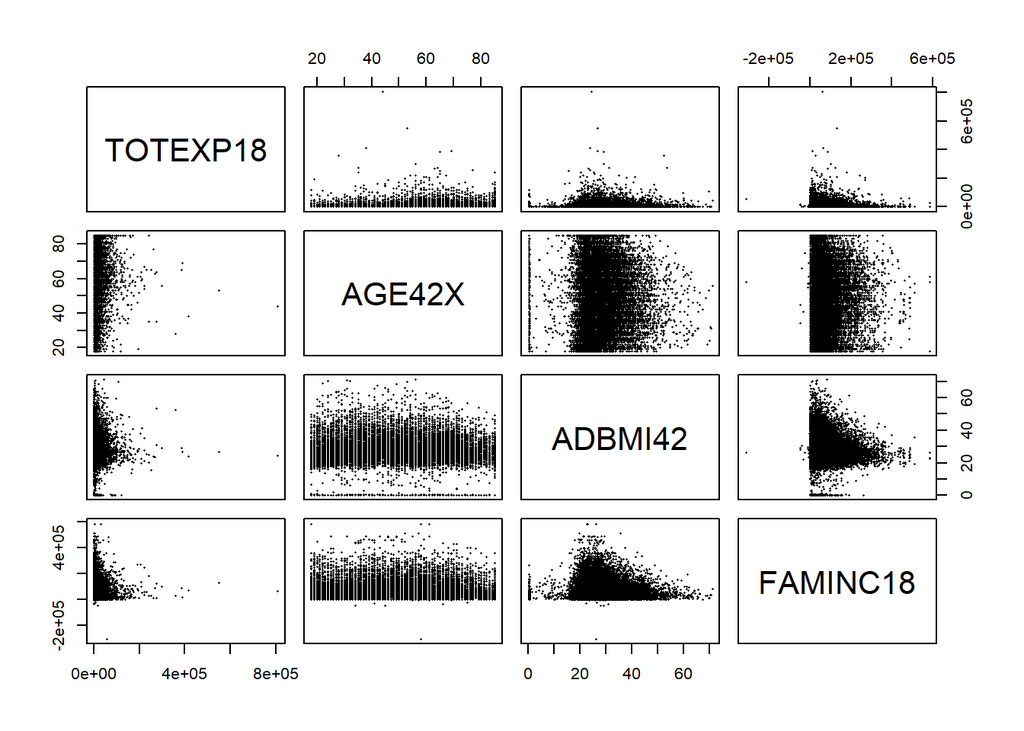

```r
# pairwise scatterplot
pairs(data[, c("TOTEXP18", "AGE42X", "ADBMI42", "FAMINC18")],
      pch = 16,
      cex = 0.3)
```

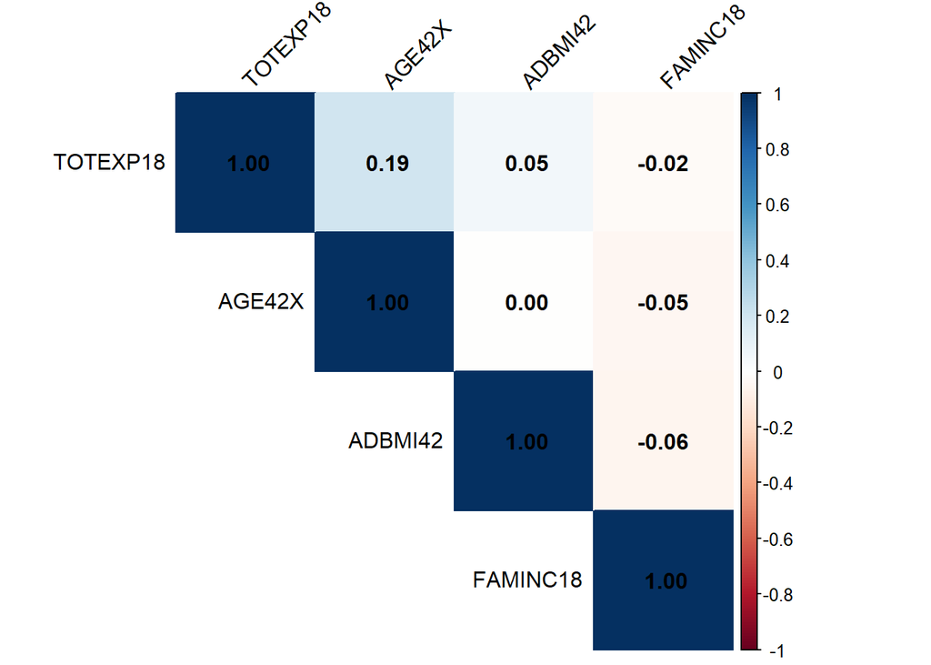

```r
# correlation matrix
cor_matrix = cor(data[, c("TOTEXP18", "AGE42X", "ADBMI42", "FAMINC18")], use = "complete.obs")
corrplot(cor_matrix, method = "color", type = "upper", tl.col = "black", tl.srt = 45, addCoef.col = "black")
```

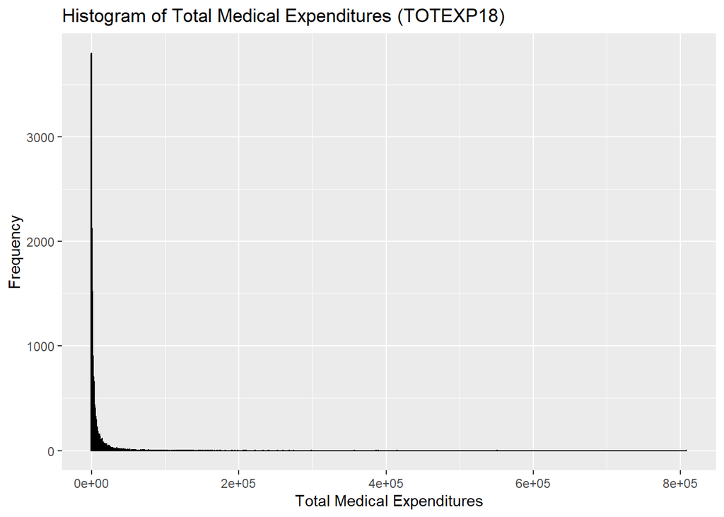

```r
# histograms for continuous variables
ggplot(data, aes(x = TOTEXP18)) +
  geom_histogram(binwidth = 500, fill = "blue", color = "black", alpha = 0.7) +
  ggtitle("Histogram of Total Medical Expenditures (TOTEXP18)") +
  xlab("Total Medical Expenditures") +
  ylab("Frequency")
```

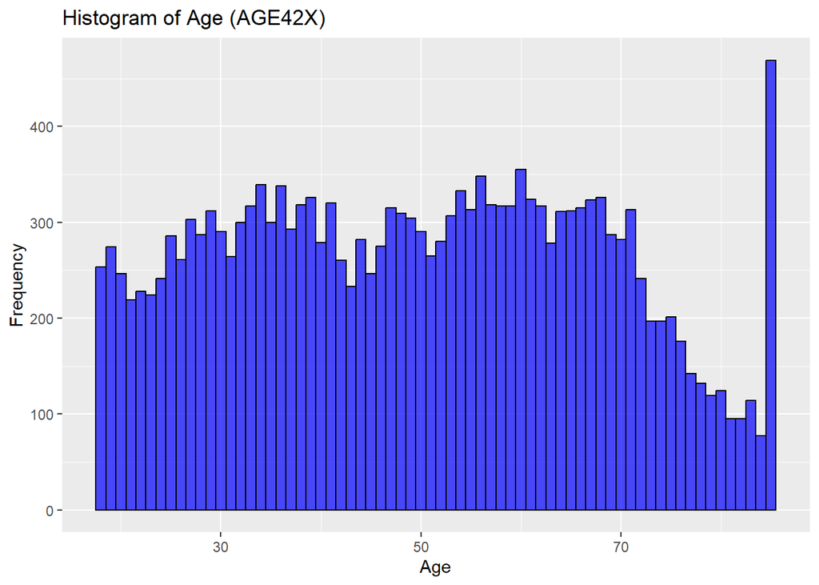

```r
ggplot(data, aes(x = AGE42X)) +
  geom_histogram(binwidth = 1, fill = "blue", color = "black", alpha = 0.7) +
  ggtitle("Histogram of Age (AGE42X)") +
  xlab("Age") +
  ylab("Frequency")
```

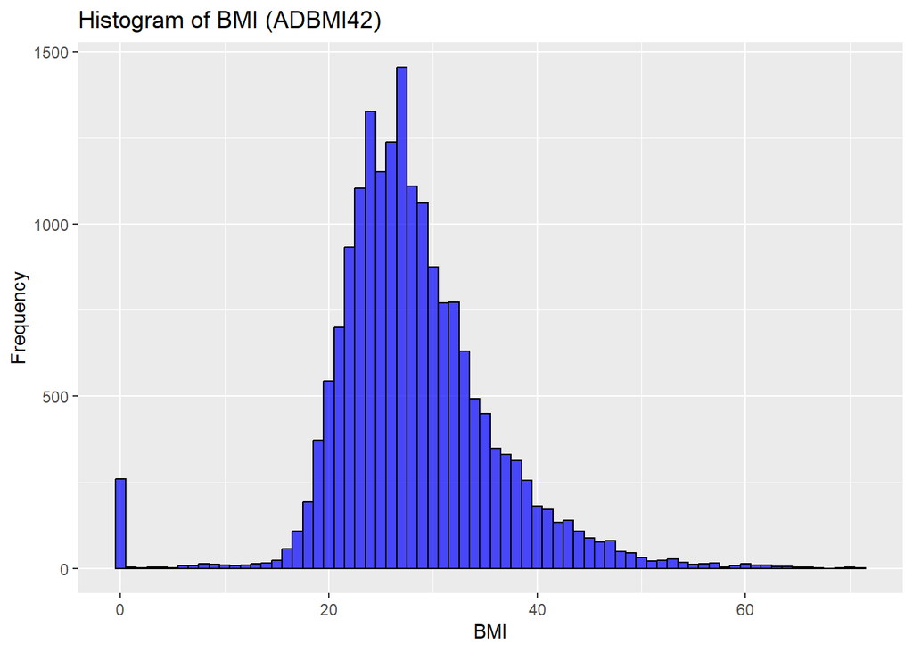

```r
ggplot(data, aes(x = ADBMI42)) +
  geom_histogram(binwidth = 1, fill = "blue", color = "black", alpha = 0.7) +
  ggtitle("Histogram of BMI (ADBMI42)") +
  xlab("BMI") +
  ylab("Frequency")
```

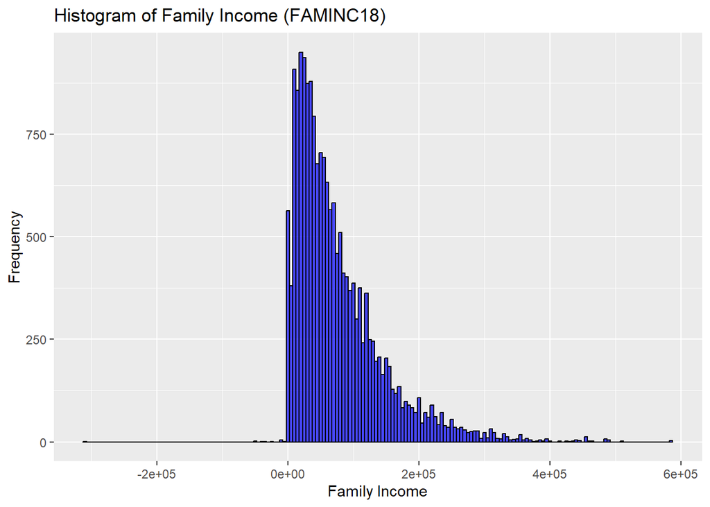

```r
ggplot(data, aes(x = FAMINC18)) +
  geom_histogram(binwidth = 5000, fill = "blue", color = "black", alpha = 0.7) +
  ggtitle("Histogram of Family Income (FAMINC18)") +
  xlab("Family Income") +
  ylab("Frequency")
```

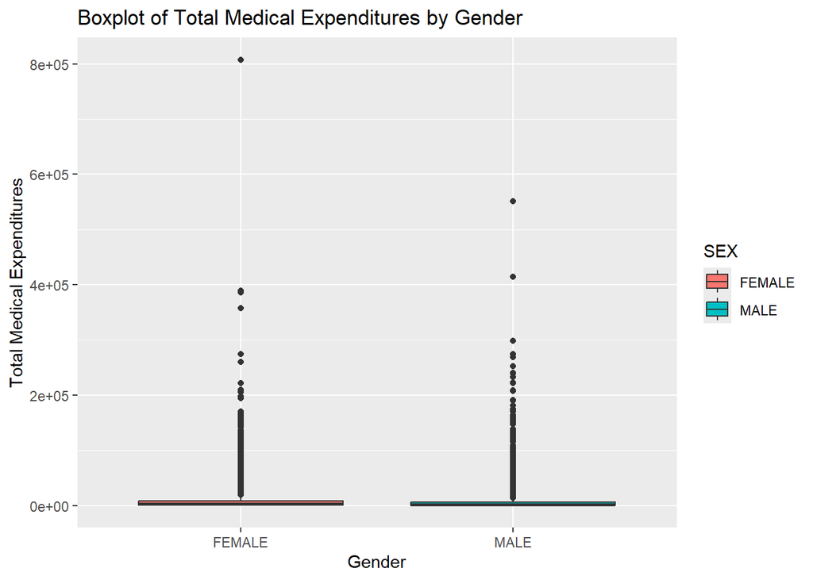

```r
# boxplot for `TOTEXP18` by gender
ggplot(data, aes(x = SEX, y = TOTEXP18, fill = SEX)) +
  geom_boxplot() +
  ggtitle("Boxplot of Total Medical Expenditures by Gender") +
  xlab("Gender") +
  ylab("Total Medical Expenditures")
```

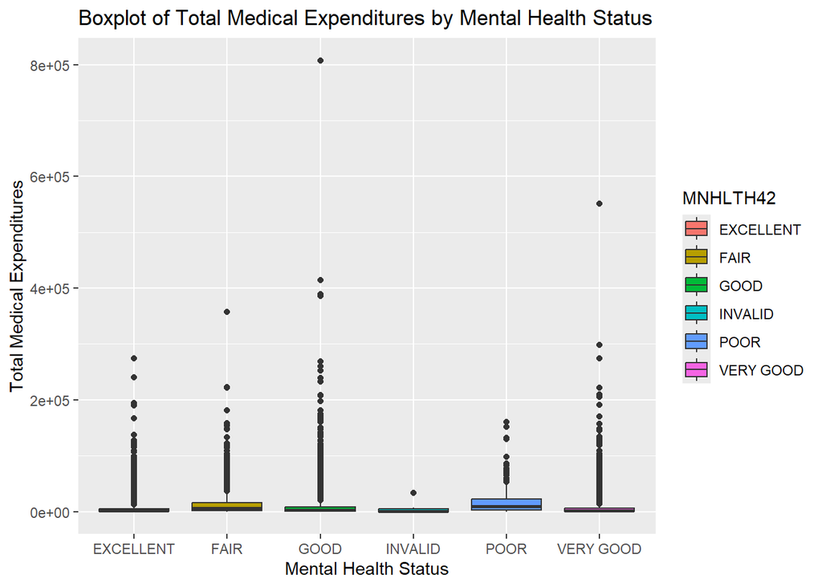

```r
# boxplot for `TOTEXP18` by perceived mental health status
ggplot(data, aes(x = MNHLTH42, y = TOTEXP18, fill = MNHLTH42)) +
  geom_boxplot() +
  ggtitle("Boxplot of Total Medical Expenditures by Mental Health Status") +
  xlab("Mental Health Status") +
  ylab("Total Medical Expenditures")
```

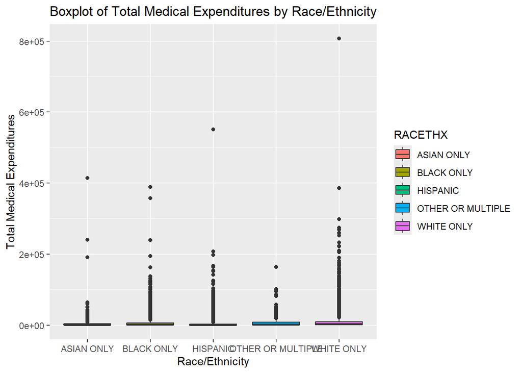

```r
# boxplot for `TOTEXP18` by race
ggplot(data, aes(x = RACETHX, y = TOTEXP18, fill = RACETHX)) +
  geom_boxplot() +
  ggtitle("Boxplot of Total Medical Expenditures by Race/Ethnicity") +
  xlab("Race/Ethnicity") +
  ylab("Total Medical Expenditures")
```

### BMI appears to have some invalid data. The histogram bar including BMIs less than 1 does not make sense.

```r
data_raw = data
data = data[data$ADBMI42 >= 1, ]
```

### Negative family income also does not make sense.

```r
data = data[data$FAMINC18 >= 0, ]
```

### Also going to remove the 6 ‘invalid’ mental health assessments.

```r
data = data[data$MNHLTH42 != 'INVALID', ]
```

### The response is heavily skewed. I want to see what it would look like with a log or box-cox transformation.

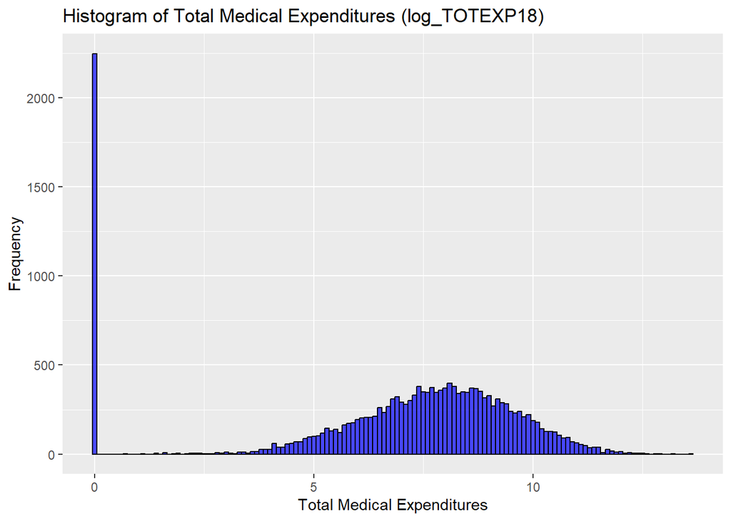

```r
# log
data$log_TOTEXP18 = log(data$TOTEXP18+1)
ggplot(data, aes(x = log_TOTEXP18)) +
  geom_histogram(binwidth = .1, fill = "blue", color = "black", alpha = 0.7) +
  ggtitle("Histogram of Total Medical Expenditures (log_TOTEXP18)") +
  xlab("Total Medical Expenditures") +
  ylab("Frequency")
```

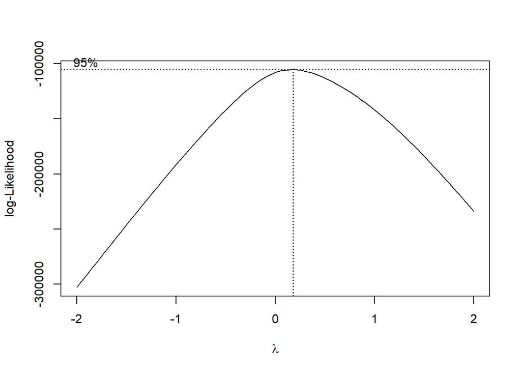

```r
# box-cox
boxcox_result <- boxcox(TOTEXP18+1 ~ 1, data = data, lambda = seq(-2, 2, by = 0.1))
```

```r
optimal_lambda <- boxcox_result$x[which.max(boxcox_result$y)]
print(optimal_lambda)
```

```
## [1] 0.1818182
```

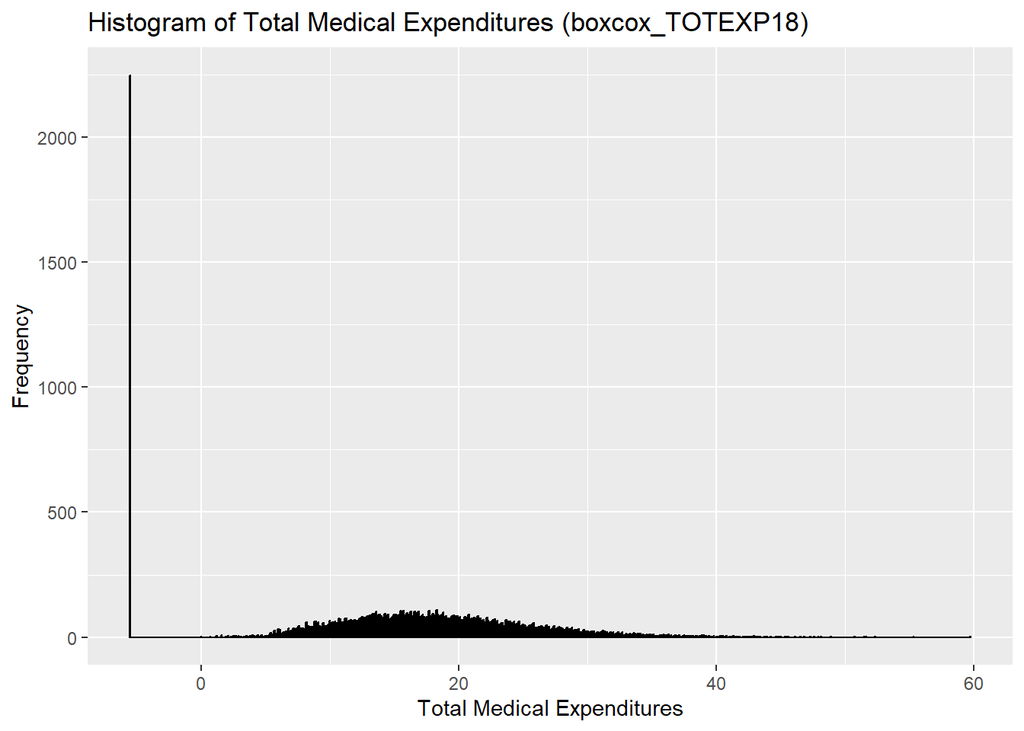

```r
data$boxcox_TOTEXP18 <- (data$TOTEXP18^optimal_lambda - 1) / optimal_lambda
ggplot(data, aes(x = boxcox_TOTEXP18)) +
  geom_histogram(binwidth = .1, fill = "blue", color = "black", alpha = 0.7) +
  ggtitle("Histogram of Total Medical Expenditures (boxcox_TOTEXP18)") +
  xlab("Total Medical Expenditures") +
  ylab("Frequency")
```

### There are a lot of people with 0 expenditure. I am going to create a binary indicator variable to consider this.

```r
# binary variable indicating whether expenditure is zero
# data$NO_EXP <- as.factor(ifelse(data$TOTEXP18 == 0, 1, 0))
```

### Actually, I am going to remove the 0 expenditure observations. I am only trying to predict non-zero expenditure amount.

```r
data = data[data$TOTEXP18 != 0, ]
```

### What about sqrt transfom of response?

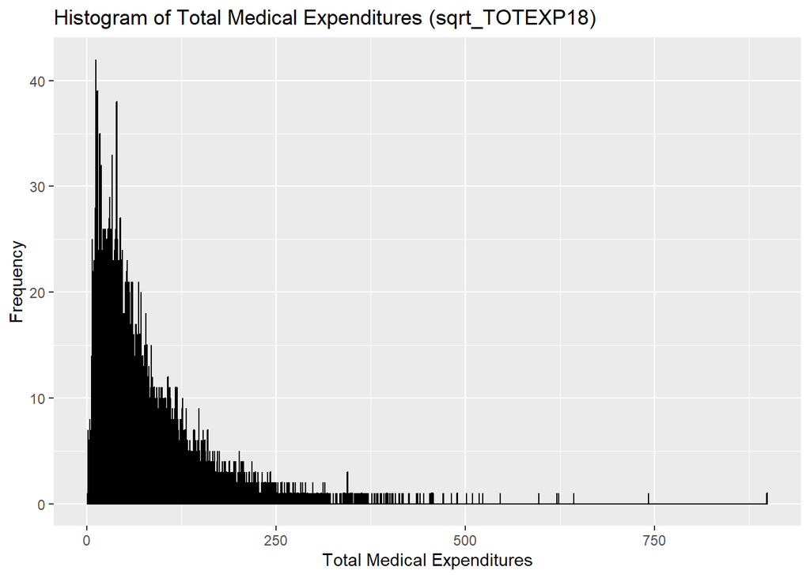

```r
# sqrt
data$sqrt_TOTEXP18 = sqrt(data$TOTEXP18)
ggplot(data, aes(x = sqrt_TOTEXP18)) +
  geom_histogram(binwidth = .1, fill = "blue", color = "black", alpha = 0.7) +
  ggtitle("Histogram of Total Medical Expenditures (sqrt_TOTEXP18)") +
  xlab("Total Medical Expenditures") +
  ylab("Frequency")
```

```r
# Nope.
data$sqrt_TOTEXP18 = NULL
```

### More pairwise scatter plots against log-transformed response

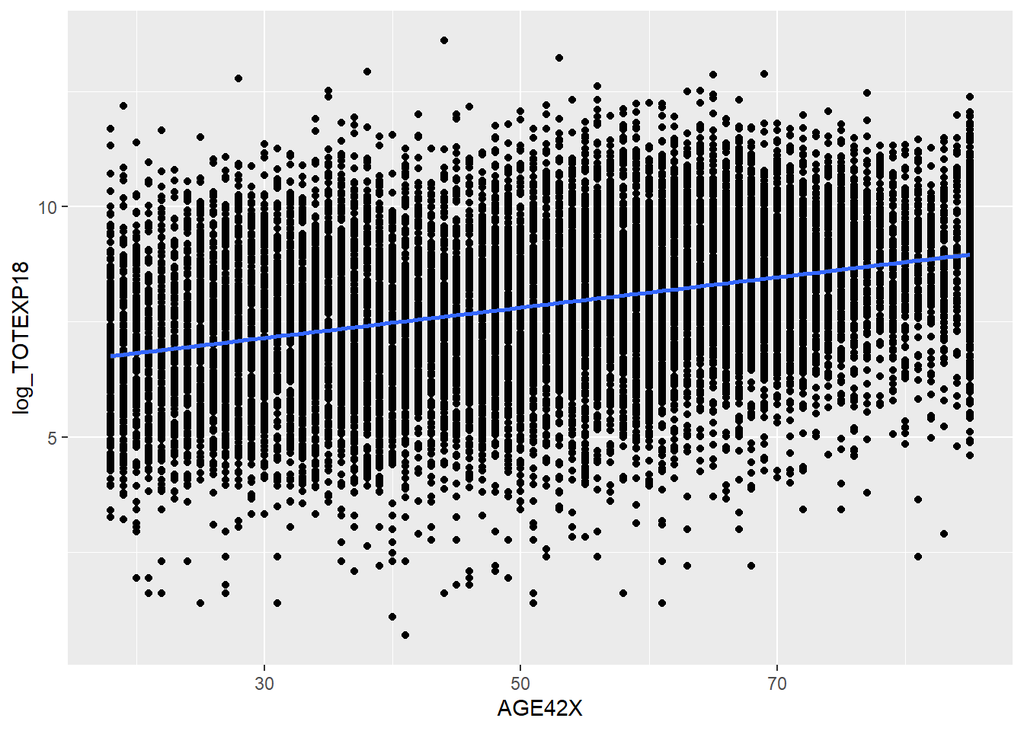

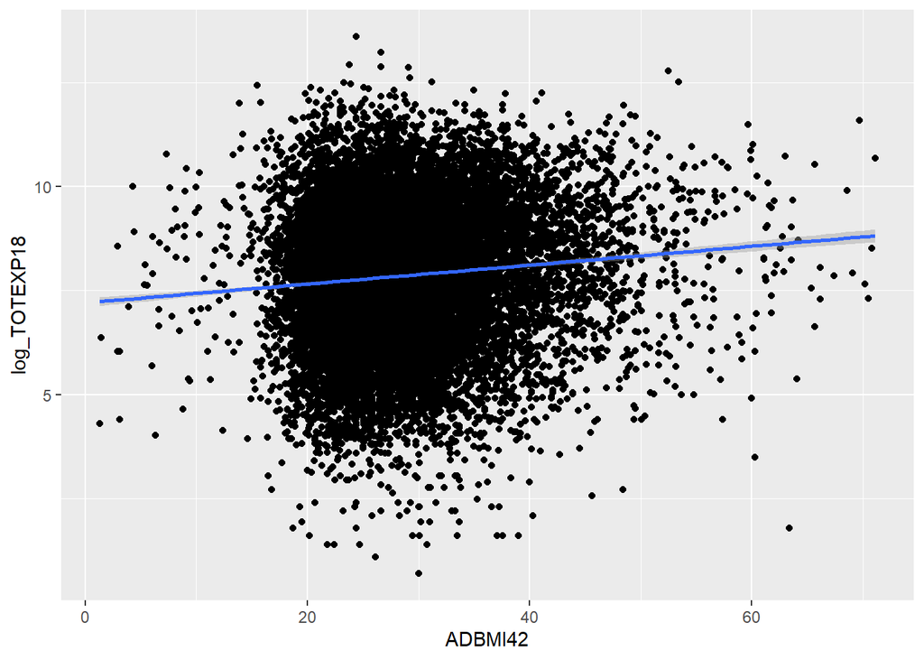

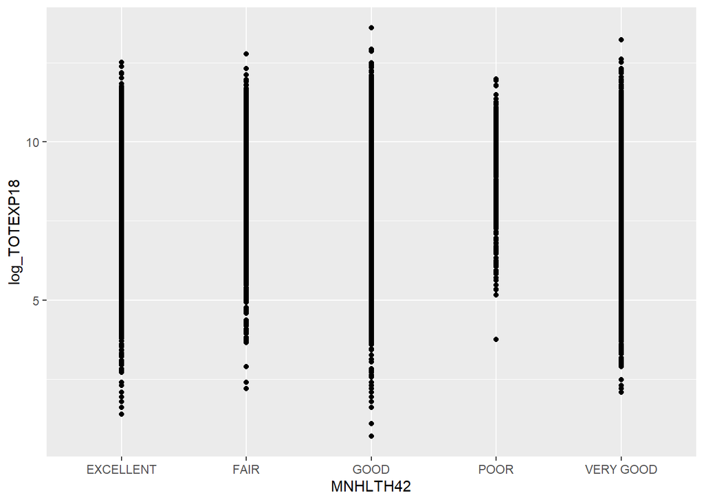

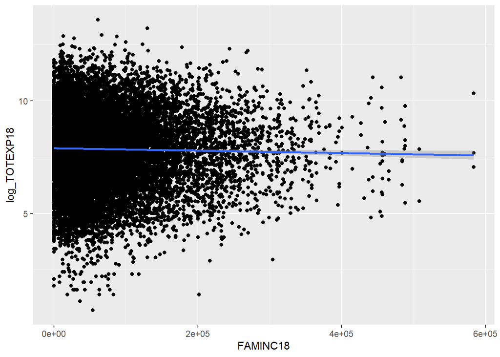

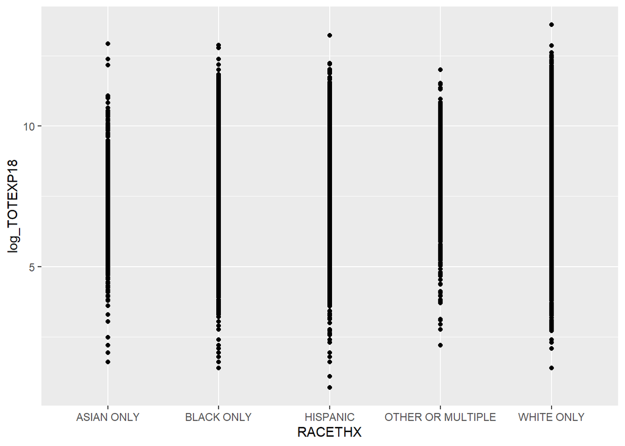

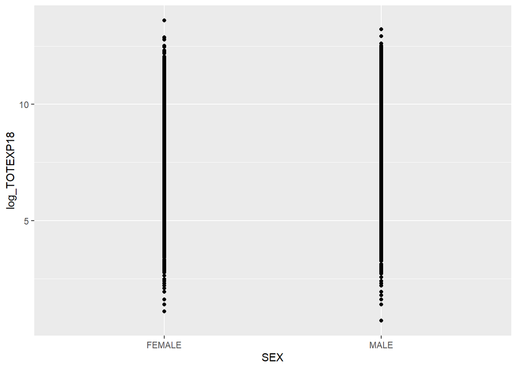

```r
for (col in colnames(data)[!colnames(data) %in% c('log_TOTEXP18', 'boxcox_TOTEXP18', 'TOTEXP18')]) {
  plot = ggplot(data, aes(x = !!sym(col), y = log_TOTEXP18)) + geom_point() + geom_smooth(method = "lm")
  print(plot)
}
```

### I will log transform and box-cox transform family income

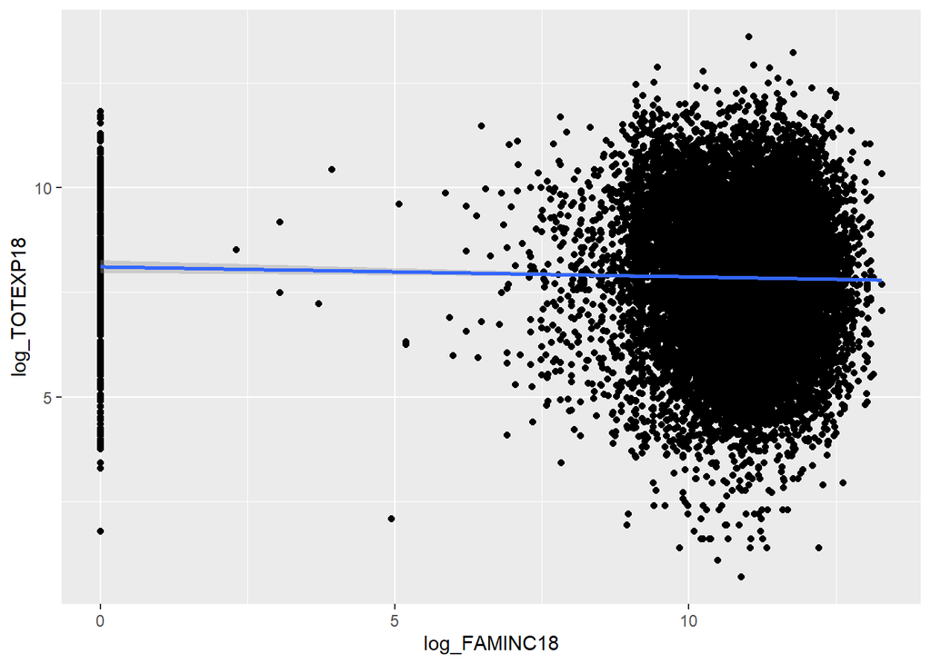

```r
# log
data$log_FAMINC18 = log(data$FAMINC18+1)
ggplot(data, aes(x = log_FAMINC18, y = log_TOTEXP18)) + geom_point() + geom_smooth(method = "lm")
```

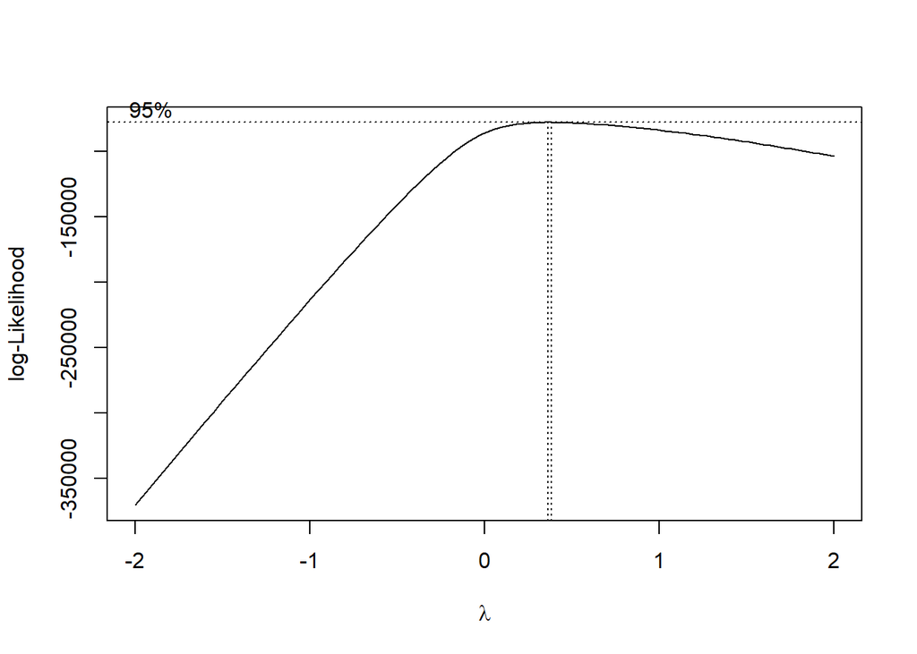

```r
# box-cox
boxcox_result <- boxcox(FAMINC18+1 ~ 1, data = data, lambda = seq(-2, 2, by = 0.1))
```

```r
optimal_lambda <- boxcox_result$x[which.max(boxcox_result$y)]
print(optimal_lambda)
```

```
## [1] 0.3838384
```

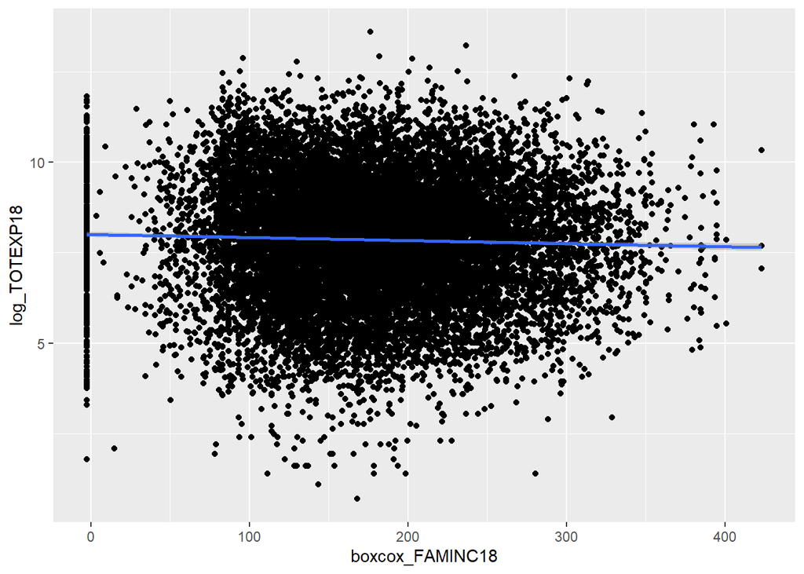

```r
data$boxcox_FAMINC18 <- (data$FAMINC18^optimal_lambda - 1) / optimal_lambda
ggplot(data, aes(x = boxcox_FAMINC18, y = log_TOTEXP18)) + geom_point() + geom_smooth(method = "lm")
```

```r
# box-cox looks better
data$log_FAMINC18 = NULL
# data$FAMINC18 = NULL
```

### There are a lot of people with very low/no family income. I am going to create a binary indicator variable to consider this.

```r
data$NO_INC <- as.factor(ifelse(data$boxcox_FAMINC18 < 0, 1, 0))
```

### I will log transform and box-cox transform BMI

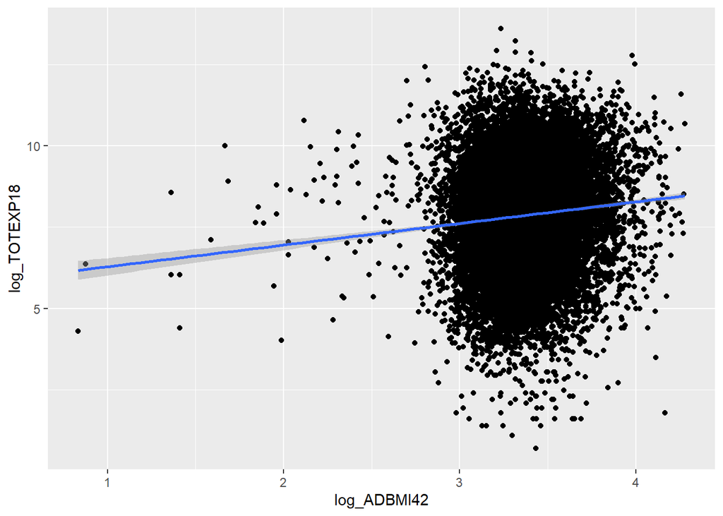

```r
# log
data$log_ADBMI42 = log(data$ADBMI42+1)
ggplot(data, aes(x = log_ADBMI42, y = log_TOTEXP18)) + geom_point() + geom_smooth(method = "lm")
```

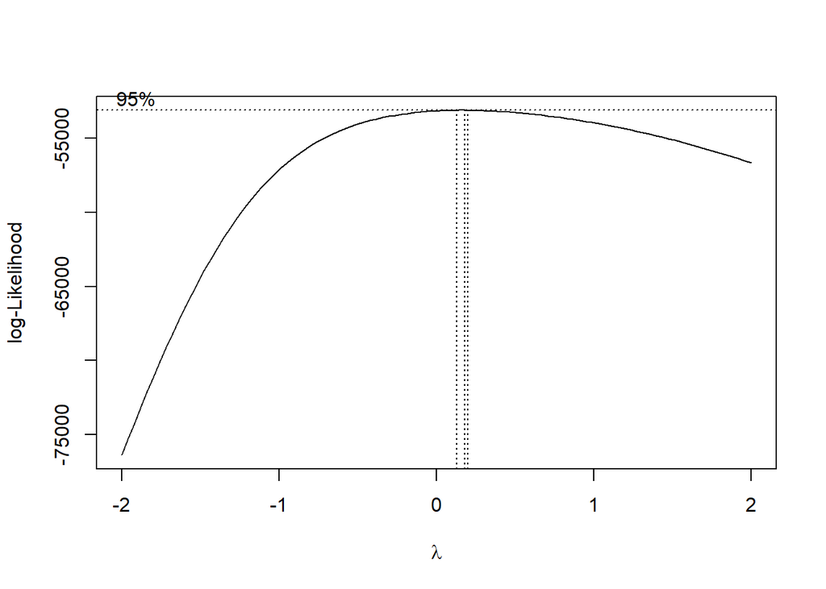

```r
# box-cox
boxcox_result <- boxcox(ADBMI42+1 ~ 1, data = data, lambda = seq(-2, 2, by = 0.1))
```

```r
optimal_lambda <- boxcox_result$x[which.max(boxcox_result$y)]
print(optimal_lambda)
```

```
## [1] 0.1818182
```

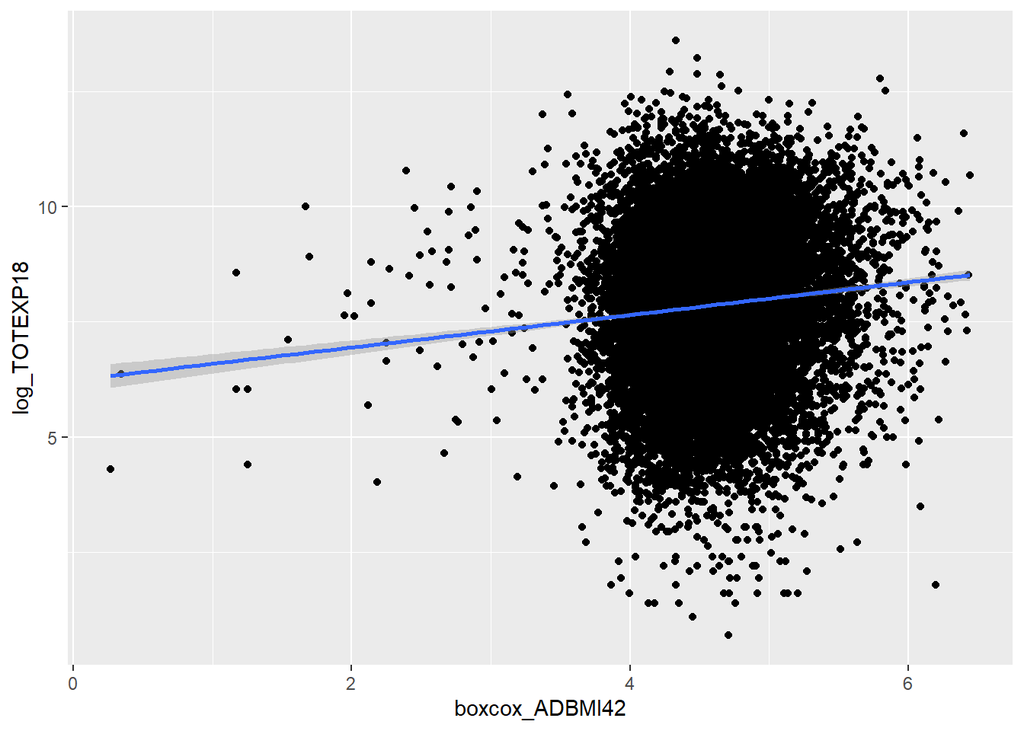

```r
data$boxcox_ADBMI42 <- (data$ADBMI42^optimal_lambda - 1) / optimal_lambda
ggplot(data, aes(x = boxcox_ADBMI42, y = log_TOTEXP18)) + geom_point() + geom_smooth(method = "lm")
```

```r
# don't love either
data$log_ADBMI42 = NULL
data$boxcox_ADBMI42 = NULL
```

### I will try to b-spline transform the BMI, Age, and Income predictors

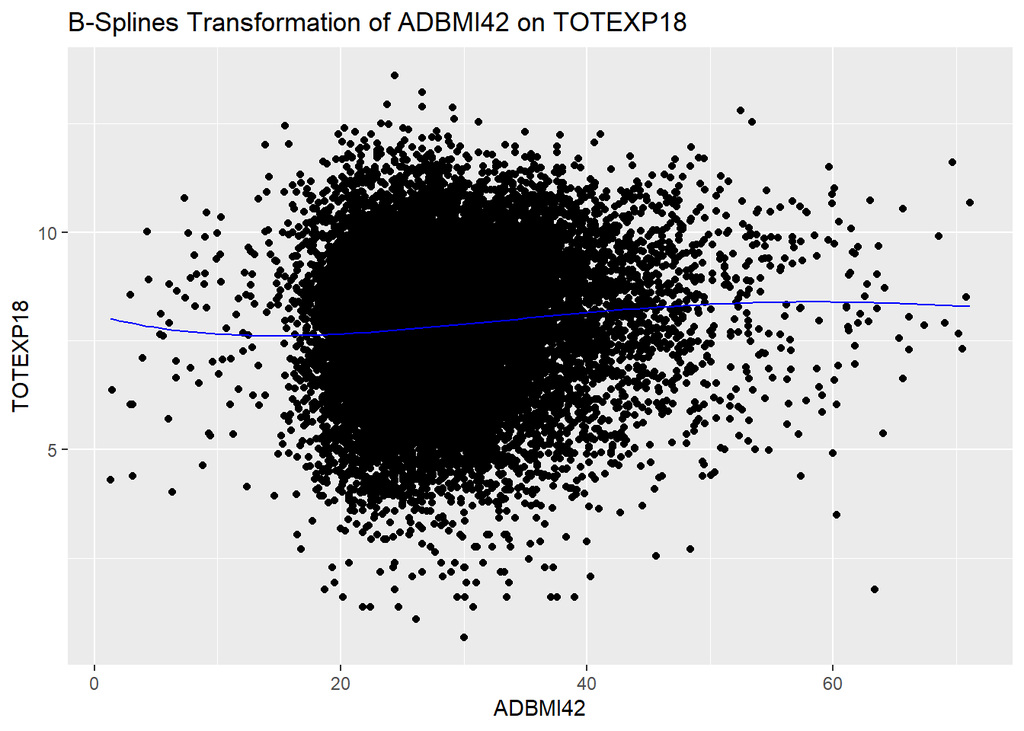

```r
# BMI
bs_model = lm(log_TOTEXP18 ~ bs(ADBMI42, degree = 4), data = data) # degree 4 looks good
new_data = data.frame(ADBMI42 = seq(min(data$ADBMI42), max(data$ADBMI42), length.out = 100))
new_data$log_TOTEXP18_pred = predict(bs_model, newdata = new_data)

# Plot the data and the fitted curve
library(ggplot2)
ggplot(data, aes(x = ADBMI42, y = log_TOTEXP18)) +
  geom_point() +
  geom_line(data = new_data, aes(x = ADBMI42, y = log_TOTEXP18_pred), color = "blue") +
  labs(title = "B-Splines Transformation of ADBMI42 on TOTEXP18",
       x = "ADBMI42", y = "TOTEXP18")
```

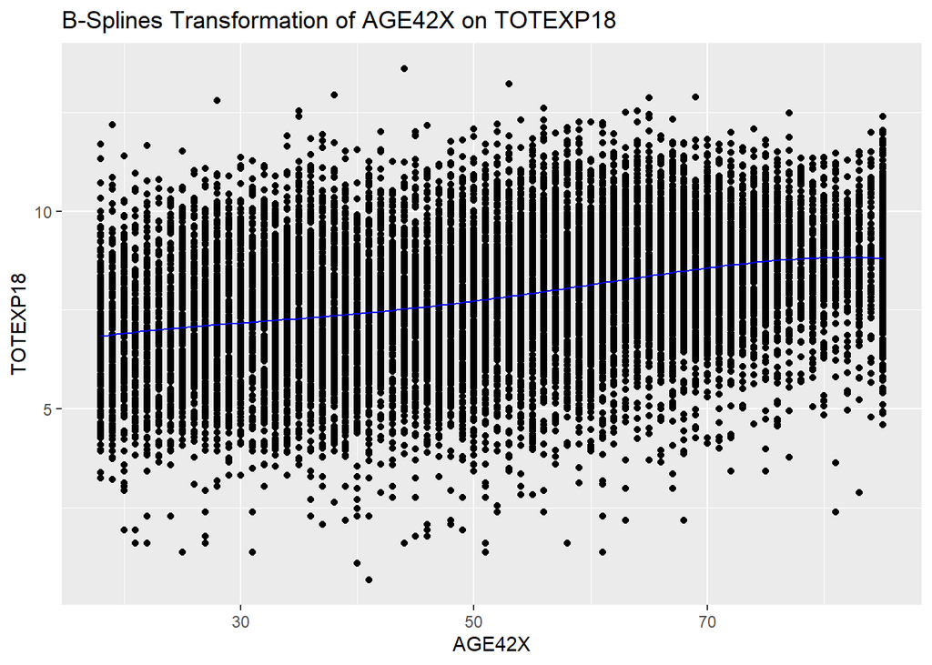

```r
# AGE
bs_model = lm(log_TOTEXP18 ~ bs(AGE42X, degree = 4), data = data) # degree 4 looks good
new_data = data.frame(AGE42X = seq(min(data$AGE42X), max(data$AGE42X), length.out = 100))
new_data$log_TOTEXP18_pred = predict(bs_model, newdata = new_data)

# Plot the data and the fitted curve
library(ggplot2)
ggplot(data, aes(x = AGE42X, y = log_TOTEXP18)) +
  geom_point() +
  geom_line(data = new_data, aes(x = AGE42X, y = log_TOTEXP18_pred), color = "blue") +
  labs(title = "B-Splines Transformation of AGE42X on TOTEXP18",
       x = "AGE42X", y = "TOTEXP18")
```

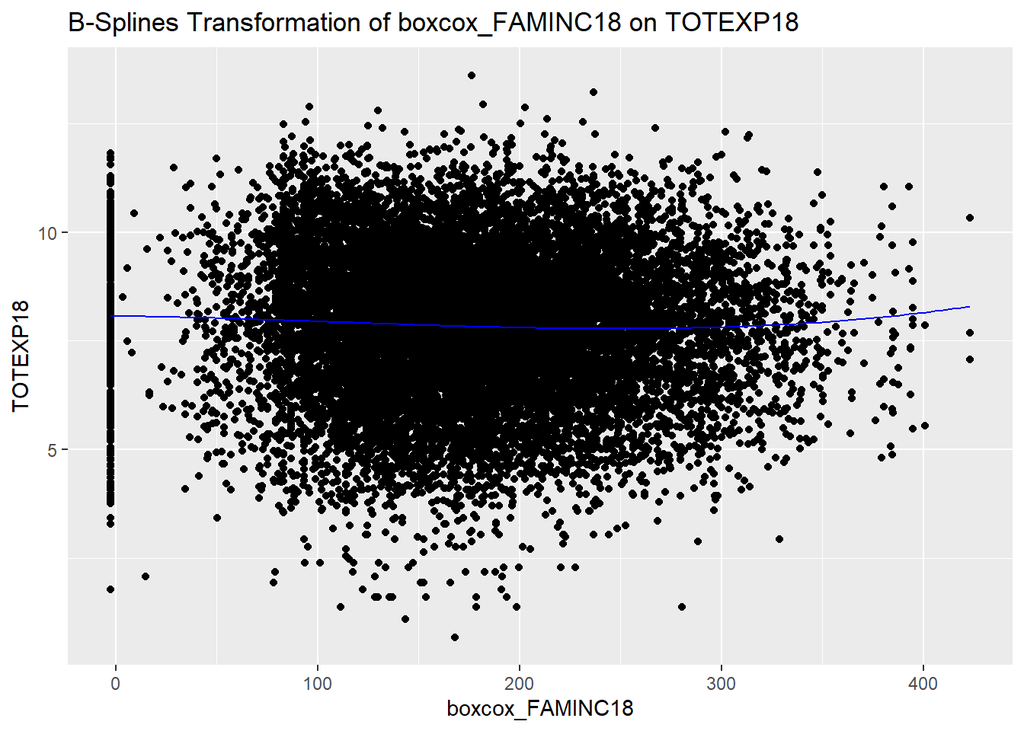

```r
# INCOME
bs_model = lm(log_TOTEXP18 ~ bs(boxcox_FAMINC18, degree = 3), data = data) # degree 3 looks good
new_data = data.frame(boxcox_FAMINC18 = seq(min(data$boxcox_FAMINC18), max(data$boxcox_FAMINC18), length.out = 100))
new_data$log_TOTEXP18_pred = predict(bs_model, newdata = new_data)

# Plot the data and the fitted curve
library(ggplot2)
ggplot(data, aes(x = boxcox_FAMINC18, y = log_TOTEXP18)) +
  geom_point() +
  geom_line(data = new_data, aes(x = boxcox_FAMINC18, y = log_TOTEXP18_pred), color = "blue") +
  labs(title = "B-Splines Transformation of boxcox_FAMINC18 on TOTEXP18",
       x = "boxcox_FAMINC18", y = "TOTEXP18")
```

### I will also try to quadratic transform the BMI predictor

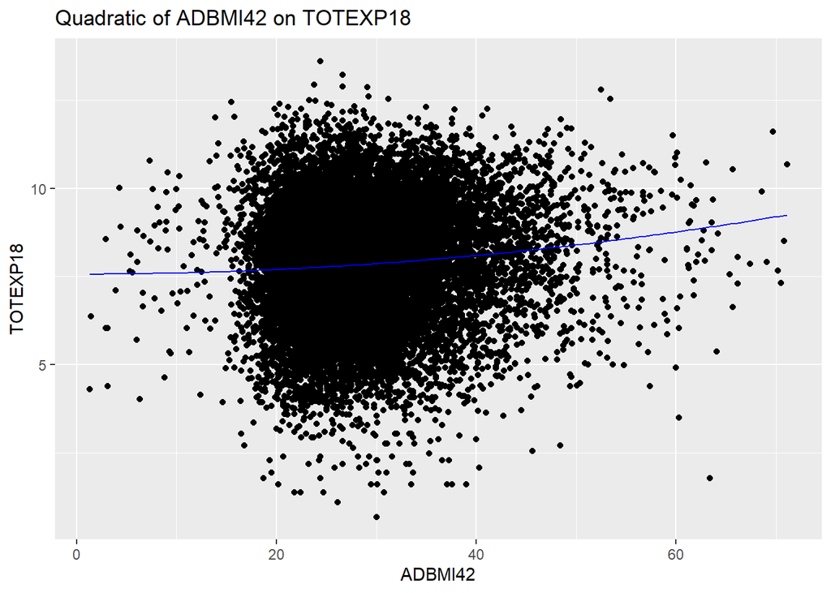

```r
bs_model = lm(log_TOTEXP18 ~ I(ADBMI42^2), data = data)
new_data = data.frame(ADBMI42 = seq(min(data$ADBMI42), max(data$ADBMI42), length.out = 100))
new_data$log_TOTEXP18_pred = predict(bs_model, newdata = new_data)

# Plot the data and the fitted curve
library(ggplot2)
ggplot(data, aes(x = ADBMI42, y = log_TOTEXP18)) +
  geom_point() +
  geom_line(data = new_data, aes(x = ADBMI42, y = log_TOTEXP18_pred), color = "blue") +
  labs(title = "Quadratic of ADBMI42 on TOTEXP18",
       x = "ADBMI42", y = "TOTEXP18")
```

```r
# This might be better than the b-spline
```

### Final plots of transformed variables

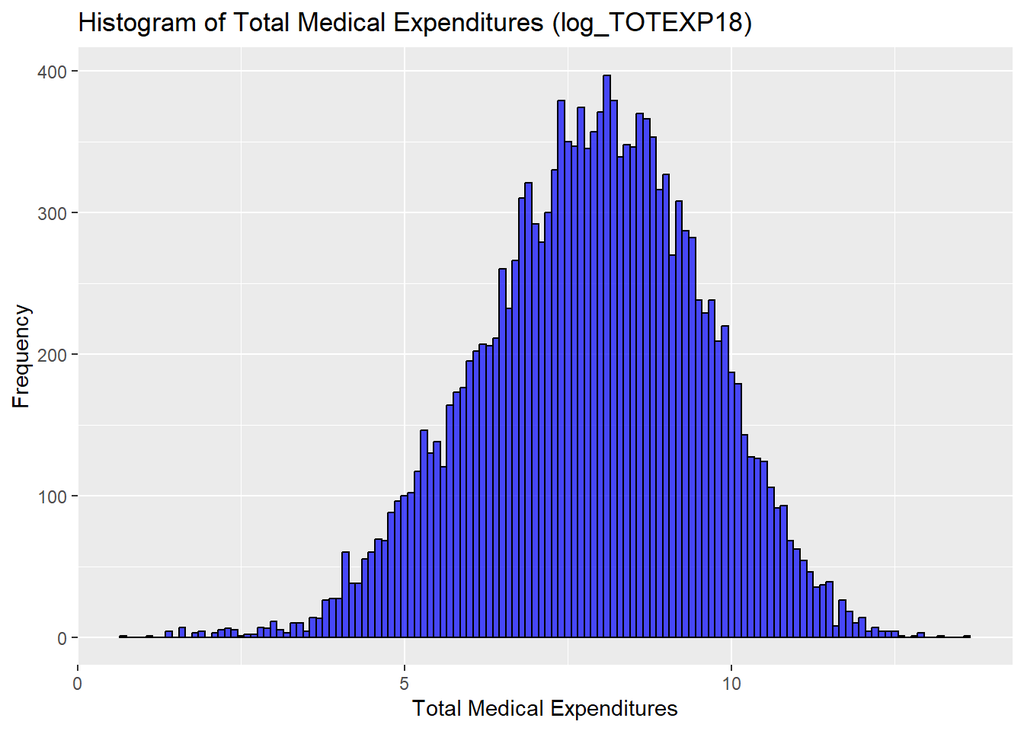

```r
ggplot(data, aes(x = log_TOTEXP18)) +
  geom_histogram(binwidth = .1, fill = "blue", color = "black", alpha = 0.7) +
  ggtitle("Histogram of Total Medical Expenditures (log_TOTEXP18)") +
  xlab("Total Medical Expenditures") +
  ylab("Frequency")
```

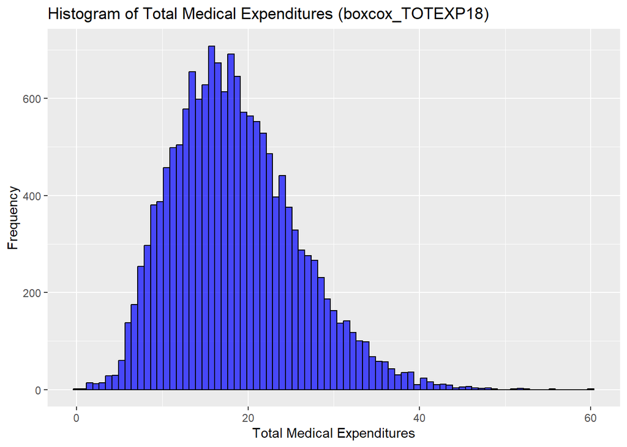

```r
ggplot(data, aes(x = boxcox_TOTEXP18)) +
  geom_histogram(binwidth = .75, fill = "blue", color = "black", alpha = 0.7) +
  ggtitle("Histogram of Total Medical Expenditures (boxcox_TOTEXP18)") +
  xlab("Total Medical Expenditures") +
  ylab("Frequency")
```